# From Baskets to Insights: Segmenting Customers Based on Purchase Behavior with K-Means and Hierarchical Clustering

#### Vaishnavi Shankar Devadig 2023

### Introduction:

In today's data-driven world, understanding our customers is the key to unlocking effective marketing strategies. In this project, I delve into the realm of supermarket customer behavior, utilizing a comprehensive dataset featuring purchase patterns, demographics, and promotional engagement. By applying clustering techniques, I aim to segment the customer base into distinct groups based on their unique characteristics and buying habits. This in-depth segmentation opens doors to targeted marketing campaigns that resonate with specific customer preferences, ultimately boosting engagement and increasing sales.

##### Dataset:

The "ifood" dataset is used to segregate customers based on purchase history.

```python
df.isnull().sum()
```

```python
Income                  0
Kidhome                 0
Teenhome                0
Recency                 0
MntWines                0
MntFruits               0
MntMeatProducts         0
MntFishProducts         0
MntSweetProducts        0
MntGoldProds            0
NumDealsPurchases       0
NumWebPurchases         0
NumCatalogPurchases     0
NumStorePurchases       0
NumWebVisitsMonth       0
AcceptedCmp3            0
AcceptedCmp4            0
AcceptedCmp5            0
AcceptedCmp1            0
AcceptedCmp2            0
Complain                0
Z_CostContact           0
Z_Revenue               0
Response                0
Age                     0
Customer_Days           0
marital_Divorced        0
marital_Married         0
marital_Single          0
marital_Together        0
marital_Widow           0
education_2n Cycle      0
education_Basic         0
education_Graduation    0
education_Master        0
education_PhD           0
MntTotal                0
MntRegularProds         0
AcceptedCmpOverall      0
dtype: int64
```

There are no null values, however few columns like **Z_CostContact** and **Z_revenue** need to be eliminated as they do not contribute to the segementation.

Additionally, we add new columns namely Relationship? and Advanced Education?, with values 0 and 1 suggesting Yes or No and the other columns like marital_Married and education_PhD are eliminated.

##### Income Histogram:

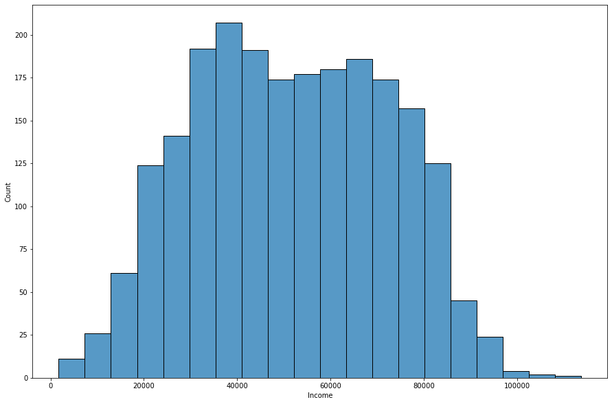

```python
print("Skewness: ",  df['Income'].skew())
print("Kurtosis: ",  df['Income'].kurt())
```

Skewness: 0.012251050882147308

Kurtosis: -0.8462133289546081

Taking a look at the Skewness value, we can state that the distribution is near symmetrical with a slightly longer positive tail, which is pretty evident in the histogram. The Kurtosis value is -0.846213 indicating a flatter peak compared to a normal distribution, as well as shorter tails. Henceforth we could state that not a lot of extremities can be observed in the values.

##### Age Histogram:

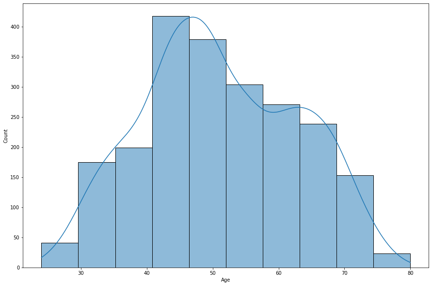

Skewness: 0.09122721532989637

Kurtosis: -0.7961248628270488

We see similar results with the Age column as well. There is very mild positive skewness but the distribution is almost symmetric. The Kurtosis value indicates a platykurtic distribution thus resulting in relatively fewer extreme values for Age.

##### Total Amount Spent Histogram:

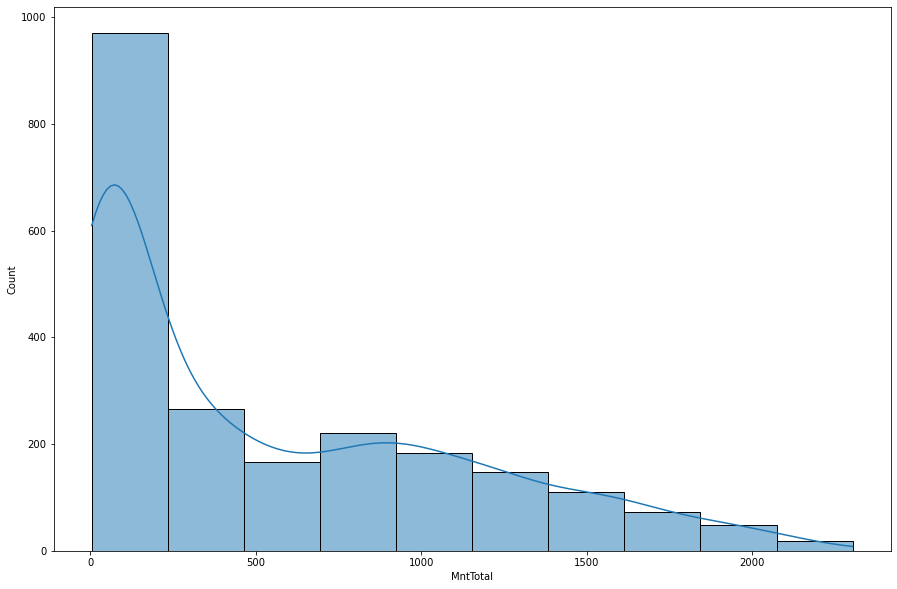

Skewness: 0.9001607067107206

Kurtosis: -0.2849579259835795

This one was almost understood, as the total amount spent increased, the number of entities engaging in it would decrease. Hence the right-skewed distribution but with lesser number of extreme values.

##### Scaling all the features and applying PRINCIPAL COMPONENT ANALYSIS:

```python
df1['pc1']
```

```python
0       1.710822
1      -0.300078
2       1.004652
3      -1.672400
4      -0.175314
          ...
2200    1.028336
2201    0.876200
2202    0.749240
2203    1.197025
2204    0.004470
Name: pc1, Length: 2202, dtype: float64
```

```python
df1['pc2']
```

```python
0      -0.518162
1      -1.606820
2      -0.004792
3       0.135624
4       0.497152
          ...
2200    0.187029
2201   -1.209149
2202    0.521543
2203   -0.460359
2204   -1.069295
Name: pc2, Length: 2202, dtype: float64
```

### Clustering Techniques Used:

### K-Means Clustering:

K-Means Clustering is a 'Centroid based' Unsupervised Learning Algorithm and its main task is to divide the datapoints we have to internally cohesive and mutually distinct clusters.

Methodology:

- Choose the desired number of clusters (k) or use the elbow method to identify the optimal number of clusters. Randomly select k data points as initial cluster centroids.

- Calculate the distance between each data point and all centroids. Assign each data point to the cluster with the nearest centroid. Iteratively performed to recompute centroids for all clusters.

Fun example, imagine we are at a party and we need to group ourselves based on our unique quirks, (Mine is random nose flaring, whats yours?). K-means is a party host, but a slightly mischievous one at that. Three random people are chosen and declared them the "group leaders." Now, everyone has to join the leader nearest them, forming three initial groups. But here comes a twist! The leaders themselves are changed based on who joins their group, becoming the average of everyone around them. So, someone with a hair-eating habit might end up leading one of the groups.

The whole charade repeats, with people switching groups if the new leader is a better fit.

In the end, you have three (or however many the host chooses) distinct groups based on their "weird habits." K-means does the same thing with data, but instead of thumb-sucking, it uses things like purchase history and website clicks. It helps businesses understand their customers better, like figuring out who buys the most pickles (and why!).

So, the next time you see a product recommendation that's oddly specific, remember, it might just be the mischievous hand of K-means at work, playing its party game with your data!

##### Applying Elbow Method and Silhoutte Score to identify the optimal number of clusters:

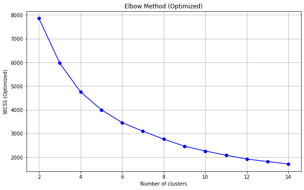

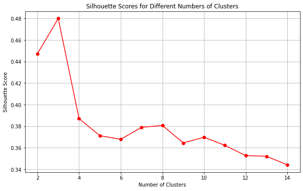

Optimal number of clusters = 3

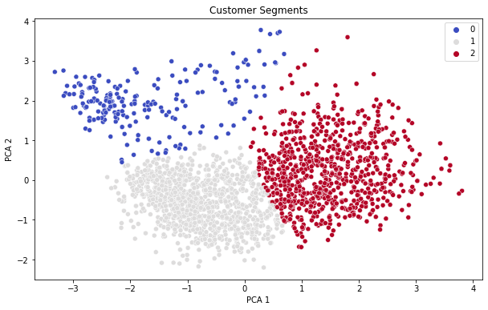

```python
plt.figure(figsize=(10, 6))
sns.scatterplot(x=pca_res[:, 0], y=pca_res[:, 1], hue=cluster_labels, palette='coolwarm')
plt.title('Customer Segments')
plt.xlabel('PCA 1')
plt.ylabel('PCA 2')
plt.show()
```

##### Results of K-Means Clustering:

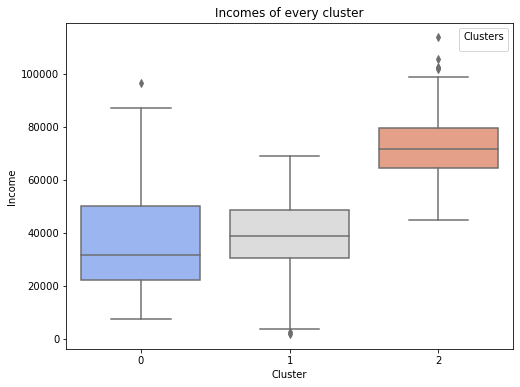

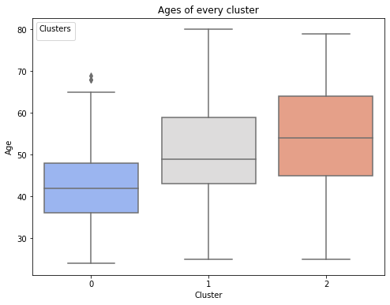

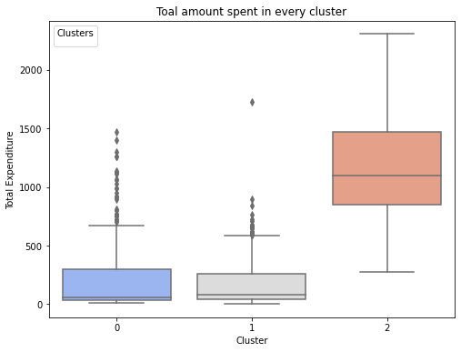

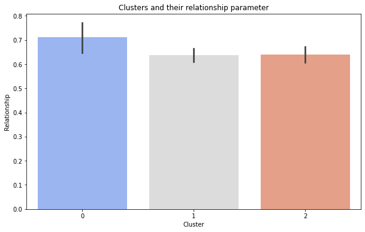

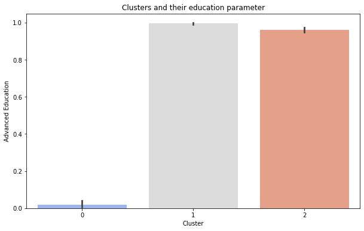

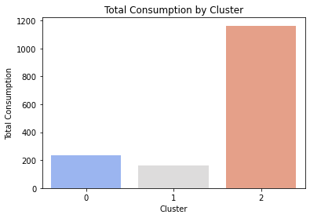

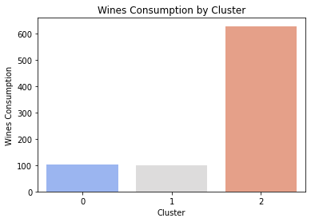

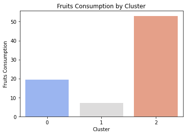

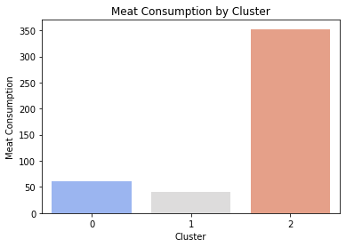

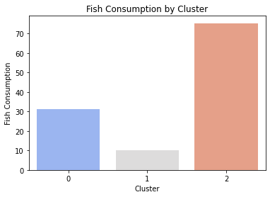

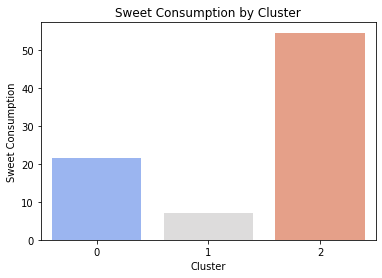

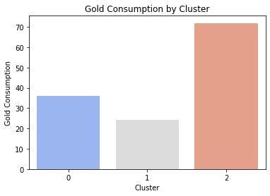

##### Table representing cluster features:

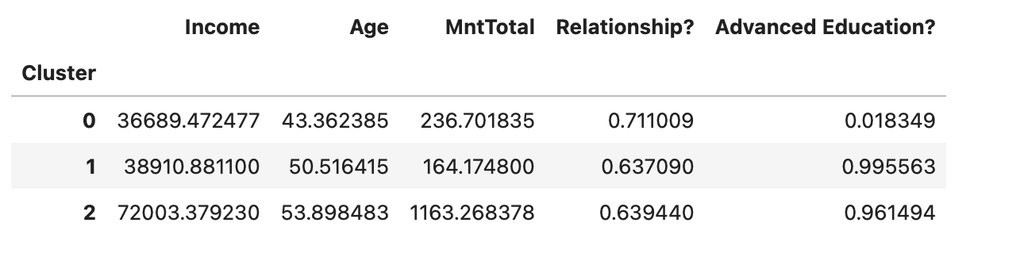

#### Final Results:

#### Cluster 0:

This cluster is characterized by the lowest average income among the clusters at approximately 36,689.47, with members having an average age of 43.36 years and an average total expenditure of about 236.70. A significant majority of this cluster's members are in a relationship (71.1%), but only a minimal fraction (1.83%) have advanced education. This cluster may represent younger, less affluent individuals or couples, potentially at the early stages of their careers, with modest spending habits and limited advanced educational background.

#### Cluster 1:

Members of this cluster have a slightly higher average income of around 38,910.88, with an older average age of 50.52 years, and the lowest average total expenditure of the clusters at 164.17. Most individuals in this cluster are also in a relationship (63.71%), but in stark contrast to Cluster 0, nearly all members (99.56%) possess advanced education. This group could reflect mature, educated individuals or couples who are conservative in their spending, possibly prioritizing savings or investment over consumerism despite their higher educational attainment.

#### Cluster 2:

This cluster comprises the most affluent group, with a high average income of approximately 72,003.38, an average age of 53.90 years, and significantly higher average total expenditure of 1,163.27. Similar to the other clusters, a majority of the individuals are in a relationship (63.94%), and a large proportion (96.15%) have advanced education. This cluster likely represents financially secure, older individuals or couples with substantial spending power, reflecting their affluent status and high level of education.

### Hierarchical Clustering:

Hierarchical Clustering is a tree-based unsupervised learning algorithm to create a hierarchy of clusters, organizing data points from individual elements to a single cluster encompassing everything.

Methodology:

- Each data point representing a customer is initially a separate cluster.
- Based on Euclidian Distances, a linkage matrix is generated.
- Ward linkage considers both inter-cluster distance (between clusters) and intra-cluster variance.
- Merging minimizes the increase in both, ensuring newly formed clusters remain cohesive.
- These two clusters merge into a single larger cluster.
- The linkage matrix and internal representations of merged clusters are updated accordingly.
- This iterative merging process continues until all data points belong to a single cluster. The merging history is visualized as a dendrogram, a tree-like structure depicting the hierarchical relationships between clusters at different merging stages.

Another cool example, imagine a party where everyone's a data point. Hierarchical clustering is like finding friend groups based on how people naturally mingle. Each data point is its own "friend group", we then look for data points most similar to each other (like two people sharing inside jokes). We merge them into one "friend group."

We repeat this until everyone's connected. We go on finding and merging the closest groups, forming larger and larger groups.

We finally stop at the "cool kids" table, as we don't want everyone in one giant group, so we choose a level in the "friend group tree" (dendrogram) that represents the desired number of clusters.

Now, these clusters are like different customer segments in marketing. You can target specific groups with tailored campaigns, just like how jokes at the "cool kids" table might not resonate with the "bookworm corner."

We use the same dataset, with the same preprocessing and transformation.

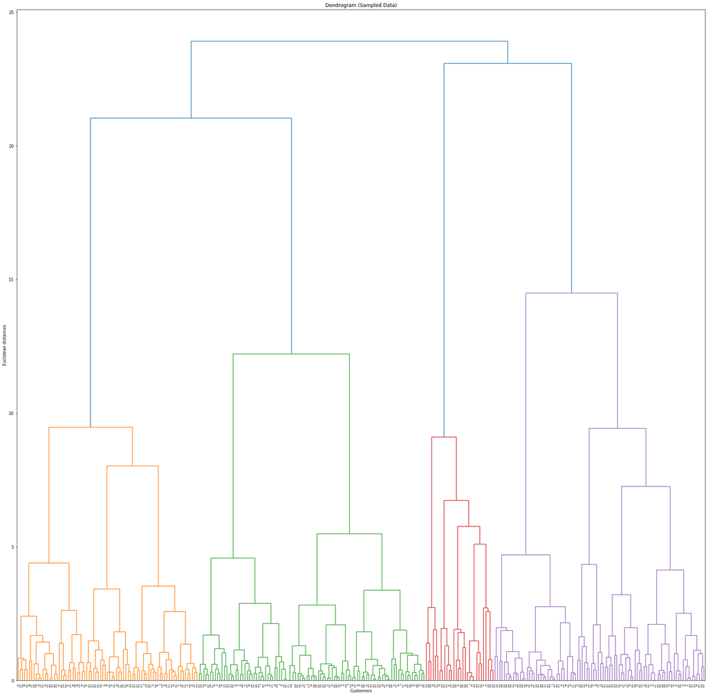

```python
import numpy as np
sample_size = 300
if len(df) < sample_size:
    sample = scaled_features
else:
    np.random.seed(42)
    indices = np.random.choice(len(scaled_features), size=sample_size, replace=False)
    sample = scaled_features[indices]
plt.figure(figsize=(30,30))
dendrogram_sample = sch.dendrogram(sch.linkage(sample, method='ward'))
plt.title('Dendrogram (Sampled Data)')
plt.xlabel('Customers')
plt.ylabel('Euclidean distances')
plt.show()
```

```python
distance_threshold = 0.7 * max(sch.linkage(scaled_features, method='ward')[:,2])
clusters = fcluster(sch.linkage(scaled_features, method='ward'), distance_threshold, criterion='distance')
optimal_cluster_number = np.max(clusters)
optimal_cluster_number
```

4

Using Agglomerative Clustering:

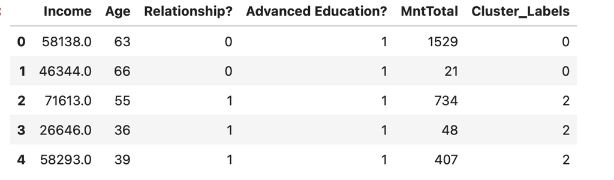

#### Final Results:

#### Cluster 0:

This cluster represents individuals with an average total expenditure of approximately 590.58, a mean income of around 52,820.36, and an average age of 51.70 years. All individuals in this cluster are not in a relationship (Relationship? = 0) and have advanced education (Advanced Education? = 1). This group may represent single, well-educated professionals in their early fifties, who have moderate spending habits.

#### Cluster 1:

Members of this cluster have a higher average total expenditure of about 1,246.56, with a significantly higher mean income of approximately 73,916.15 and an average age of 54.03 years. All individuals in this cluster are in a relationship (Relationship? = 1) and possess advanced education (Advanced Education? = 1). This cluster likely consists of older, affluent couples who are well-educated and exhibit higher spending.

#### Cluster 2:

This cluster is characterized by the lowest average total expenditure (233.83) among the groups, with a mean income of 41,810.03 and an average age of 50.62 years. Like Cluster 1, all individuals are in a relationship (Relationship? = 1) and have advanced education (Advanced Education? = 1). This group could represent middle-aged couples with modest incomes and spending habits, emphasizing the diversity in financial behavior even among similarly educated and relationship-committed individuals.

#### Cluster 3:

Individuals in this cluster have an average total expenditure of 367.99, with a mean income closely aligned with Cluster 2 at approximately 41,771.25 and the youngest average age of 46.21 years. The majority are in a relationship (Relationship? = 0.67), but unlike the other clusters, they do not have advanced education (Advanced Education? = 0). This cluster may represent younger individuals or couples, possibly with basic to no higher education, and exhibit low to moderate spending patterns.